# Dose-Response Linear Approximation

26-01-12

# Introduction

Here, we analyze **dose-response functions** for common enteric pathogens and define the linear range (in practice, the maximum dose of the linear range), and the equation of the line.

For each function, we:

1. Transform the dose-response curve to log-log space (log<sub>10</sub> of dose and response) to facilitate visualization
2. Compute numerical derivatives using **finite differences**: the first derivative provides the slope at each point, and the second derivative identifies inflection points.
3. Identify the inflection point, defined as the dose at which the second derivative is minimized. This point corresponds to the transition where the function begins to approximate linear behavior.
4. Fit a linear regression to the portion of the curve to the left of the inflection point, capturing the linear region.
5. Overlay the linear fit and its equation directly on the curve for visual reference.

This approach allows us to quantify the low-dose, approximately linear region of each dose-response function and compare slope and intercept parameters across different models. At the end, a summary table collates the inflection points and linear regression parameters for all evaluated functions.

```r
library(pracma)
library(kableExtra)
library(gsl)
library(ggplot2)
library(dplyr)
library(tidyr)
library(DT)
library(Cairo)
setwd("C:/Users/crankk/OneDrive - LVWATER - Las Vegas Valley Water District/EPA Reuse/DPR Nevada")
# Initialize results table
results <- data.frame(
  results=character(),
  Function=character(),
  Max_dose=numeric(),

  Linear_Intercept=numeric(),
  Linear_Slope=numeric(),
  Name=character(),
  Pathogen=character(),
  stringsAsFactors=FALSE
)
fit_list <- list()
## sequence for numerical second differentiation. If there are "wobbles", adjust the step parameter in the fderiv function not the xs parameter.
xs <- seq(-13, 6, length.out=2000)
```

# Norovirus Dose-Response Functions

```r
# -------------------------------
# Dose-response model formulas, parameters, and metadata
# -------------------------------
nov_info <- data.frame(
  Name = c(
    "Approximate Beta-Poisson",
    "Hypergeometric (Teunis 2008)",
    "Hypergeometric (Teunis 2020)",
    "Fractional Poisson (Aggregated)",
    "Fractional Poisson (No Aggregation)"
  ),
  Function = c("approx_bp", "hyper", "new_hyper", "fp_agg", "fp"),
  Formula = c(
    "y = 1 - (1 + x/b)^-a",
    "y = 1 - 1F1(alpha, alpha+beta, -x)",
    "y = 1 - 1F1(alpha_n, alpha_n+beta_n, -x)",
    "y = p * (1 - exp(-x/alpha1))",
    "y = p * (1 - exp(-x/alpha2))"
  ),
  Parameters = c(
    "a=0.104, b=32.3",
    "alpha=0.04, beta=0.055",
    "alpha_n=0.393, beta_n=0.767",
    "p=0.72, alpha1=1106",
    "p=0.72, alpha2=1"
  ),
  Citation = c(
    "Van Abel et al., 2017",
    "Teunis et al., 2008",
    "Teunis et al., 2020",
    "Messner et al., 2014",
    "Messner et al., 2014"
  ),
  stringsAsFactors = FALSE
)

# Display nicely in R Markdown
kable(nov_info, caption="Norovirus dose-response models") %>%
  kable_styling(full_width=F, position="center")
```

Norovirus dose-response models

| Name | Function | Formula | Parameters | Citation |
| --- | --- | --- | --- | --- |
| Approximate Beta-Poisson | approx_bp | y = 1 - (1 + x/b)^-a | a=0.104, b=32.3 | Van Abel et al., 2017 |
| Hypergeometric (Teunis 2008) | hyper | y = 1 - 1F1(alpha, alpha+beta, -x) | alpha=0.04, beta=0.055 | Teunis et al., 2008 |
| Hypergeometric (Teunis 2020) | new_hyper | y = 1 - 1F1(alpha_n, alpha_n+beta_n, -x) | alpha_n=0.393, beta_n=0.767 | Teunis et al., 2020 |
| Fractional Poisson (Aggregated) | fp_agg | y = p * (1 - exp(-x/alpha1)) | p=0.72, alpha1=1106 | Messner et al., 2014 |
| Fractional Poisson (No Aggregation) | fp | y = p * (1 - exp(-x/alpha2)) | p=0.72, alpha2=1 | Messner et al., 2014 |

## 1. Approximate Beta-Poisson

Van Abel et al 2017, alpha = 0.104, beta=32.3

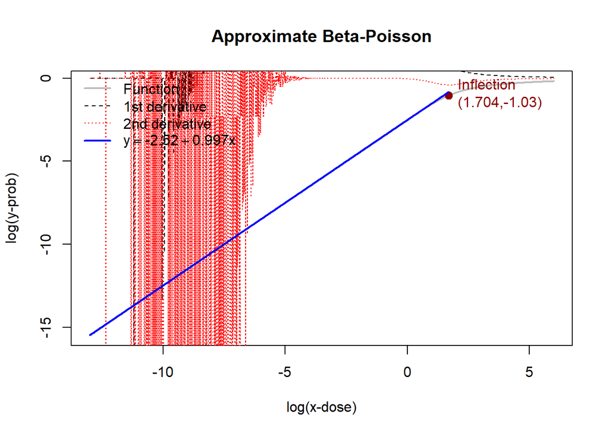

```r
# -------------------------------
# 1. Approximate Beta-Poisson (Van Abel 2017)
# -------------------------------
approx_bp <- function(x){
  x <- 10^x
  a <- 0.104
  b <- 32.3
  log10(1 - (1 + (x/b))^-a)
}


ys <- approx_bp(xs)
y1 <- fderiv(approx_bp, xs, n=1, method="backward" )
y2 <- fderiv(approx_bp, xs, n=2, method="backward")

# Inflection
inflect_idx <- which(xs > 0)[which.min(y2[xs > 0])] #visually identified range where inflection point is, bounded the search for the minimum in that area to avoid wiggles. which.min looks for rank not value.
inflect_x <- xs[inflect_idx]
inflect_y <- ys[inflect_idx]

# Plot
plot(xs, ys, type="l", col="gray", lwd=2, main="Approximate Beta-Poisson",
     xlab="log(x-dose)", ylab="log(y-prob)")
lines(xs, y1, col="black", lty=2)
lines(xs, y2, col="red", lty=3)
points(inflect_x, inflect_y, col="darkred", pch=19, cex=1.2)
text(inflect_x, inflect_y, labels=paste0("Inflection\n(", round(inflect_x,3), ",", round(inflect_y,3),")"), pos=4, col="darkred")

# Linear fit
linear_idx <- which(xs <= inflect_x)
x_linear <- xs[linear_idx]
y_linear <- ys[linear_idx]
lin_model <- lm(y_linear ~ x_linear)
y_fit <- predict(lin_model)
lines(x_linear, y_fit, col="blue", lwd=2)

# Add formula
slope <- coef(lin_model)[2]
intercept <- coef(lin_model)[1]
formula_text <- bquote(y == .(round(intercept,3)) + .(round(slope,3))*x)


# Legend
legend("topleft", legend=c("Function","1st derivative","2nd derivative",formula_text),
       col=c("gray","black","red","blue"), lty=c(1,2,3,1), lwd=c(2,1,1,2), bty="n")
```

```r
# Save results
results <- rbind(results, data.frame(
  Function="approx_bp",
  Max_dose=round(inflect_x,3),
  Linear_Intercept=round(intercept,3),
  Linear_Slope=round(slope,3),
     Name= "Approximate Beta-Poisson",
  Pathogen = "Norovirus"
))
```

## 2. Hypergeometric

Teunis et al., 2008; alpha=0.04, beta=0.055, no aggregation

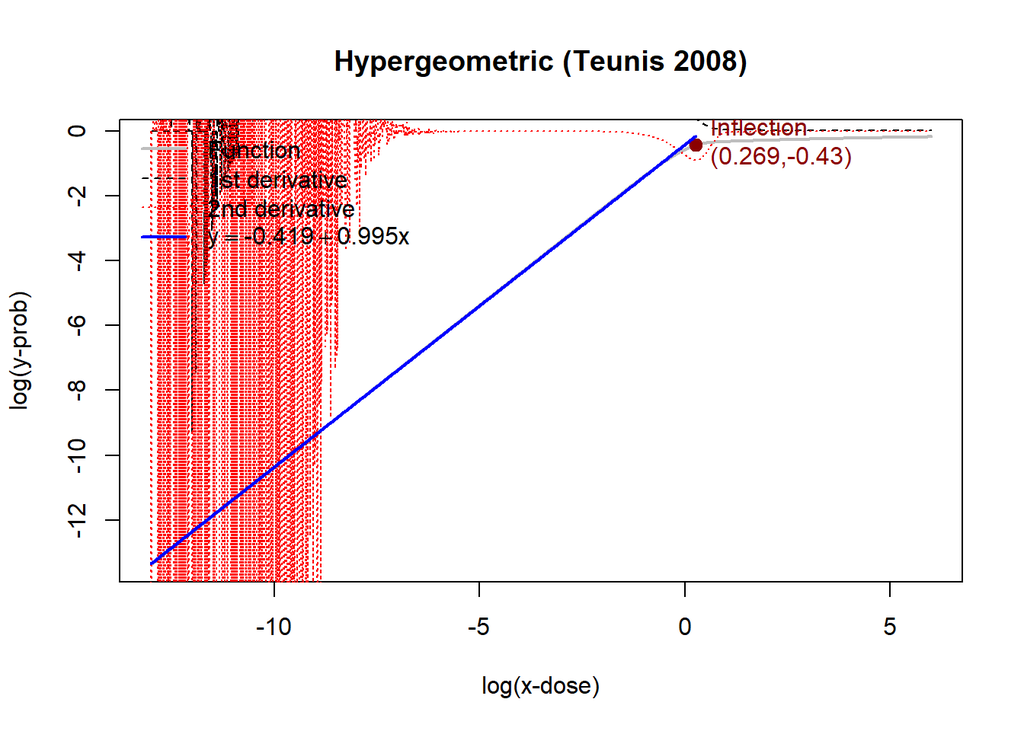

```r
# -------------------------------
# 2. Hypergeometric (Teunis 2008)
# -------------------------------
hyper <- function(x){
  x <- 10^x
  alpha <- 0.04
  beta <- 0.055
  log10(1 - hyperg_1F1(alpha, (alpha+beta), -x))
}


ys <- hyper(xs)
y1 <- fderiv(hyper, xs, n=1, method="backward")
y2 <- fderiv(hyper, xs, n=2, method="backward")

inflect_idx <- which(xs > 0)[which.min(y2[xs > 0])] #visually identified range where inflection point is, bounded the search for the minimum in that area to avoid wiggles. which.min looks for rank not value.
inflect_x <- xs[inflect_idx]
inflect_y <- ys[inflect_idx]

plot(xs, ys, type="l", col="gray", lwd=2, main="Hypergeometric (Teunis 2008)",
     xlab="log(x-dose)", ylab="log(y-prob)")
lines(xs, y1, col="black", lty=2)
lines(xs, y2, col="red", lty=3)
points(inflect_x, inflect_y, col="darkred", pch=19, cex=1.2)
text(inflect_x, inflect_y, labels=paste0("Inflection\n(", round(inflect_x,3), ",", round(inflect_y,3),")"), pos=4, col="darkred")

linear_idx <- which(xs <= inflect_x)
x_linear <- xs[linear_idx]
y_linear <- ys[linear_idx]
lin_model <- lm(y_linear ~ x_linear)
y_fit <- predict(lin_model)
lines(x_linear, y_fit, col="blue", lwd=2)

slope <- coef(lin_model)[2]
intercept <- coef(lin_model)[1]
formula_text <- bquote(y == .(round(intercept,3)) + .(round(slope,3))*x)

legend("topleft", legend=c("Function","1st derivative","2nd derivative",formula_text),
       col=c("gray","black","red","blue"), lty=c(1,2,3,1), lwd=c(2,1,1,2), bty="n")
```

```r
results <- rbind(results, data.frame(
  Function="hyper",
  Max_dose=round(inflect_x,3),
  Linear_Intercept=round(intercept,3),
  Linear_Slope=round(slope,3),
  Name="Hypergeometric (Teunis 2008)",
  Pathogen = "Norovirus"
))
```

## 3. New Hypergeometric (Teunis 2020)

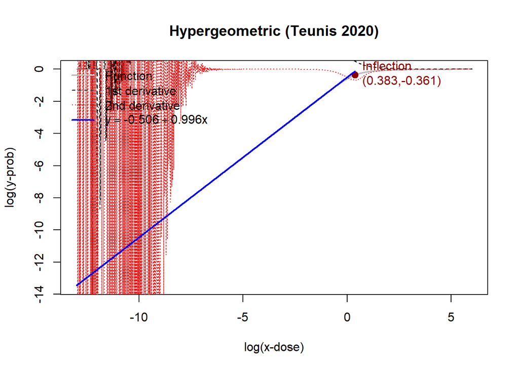

```r
# -------------------------------
# 3. New Hypergeometric (Teunis 2020)
# -------------------------------
new_hyper <- function(x){
  x <- 10^x
  alpha_n <- 0.393
  beta_n <- 0.767
  log10(1 - hyperg_1F1(alpha_n, (alpha_n + beta_n), -x))
}


ys <- new_hyper(xs)
y1 <- fderiv(new_hyper, xs, n=1, method="backward")
y2 <- fderiv(new_hyper, xs, n=2, method="backward")

inflect_idx <- which(xs > 0)[which.min(y2[xs > 0])] #visually identified range where inflection point is, bounded the search for the minimum in that area to avoid wiggles. which.min looks for rank not value.
inflect_x <- xs[inflect_idx]
inflect_y <- ys[inflect_idx]

plot(xs, ys, type="l", col="gray", lwd=2, main="Hypergeometric (Teunis 2020)",
     xlab="log(x-dose)", ylab="log(y-prob)")
lines(xs, y1, col="black", lty=2)
lines(xs, y2, col="red", lty=3)
points(inflect_x, inflect_y, col="darkred", pch=19, cex=1.2)
text(inflect_x, inflect_y, labels=paste0("Inflection\n(", round(inflect_x,3), ",", round(inflect_y,3),")"), pos=4, col="darkred")

linear_idx <- which(xs <= inflect_x)
x_linear <- xs[linear_idx]
y_linear <- ys[linear_idx]
lin_model <- lm(y_linear ~ x_linear)
y_fit <- predict(lin_model)
lines(x_linear, y_fit, col="blue", lwd=2)

slope <- coef(lin_model)[2]
intercept <- coef(lin_model)[1]
formula_text <- bquote(y == .(round(intercept,3)) + .(round(slope,3))*x)

legend("topleft", legend=c("Function","1st derivative","2nd derivative",formula_text),
       col=c("gray","black","red","blue"), lty=c(1,2,3,1), lwd=c(2,1,1,2), bty="n")
```

```r
results <- rbind(results, data.frame(
  Function="new_hyper",
  Max_dose=round(inflect_x,3),
  Linear_Intercept=round(intercept,3),
  Linear_Slope=round(slope,3),
   Name="Hypergeometric (Teunis 2020)",
  Pathogen = "Norovirus"
))
```

## 4. Fractional Poisson (Aggregated)

Messner et al., 2014; Atmar et al., 2014; Atmar et al., 2008; P=0.72, alpha=1106

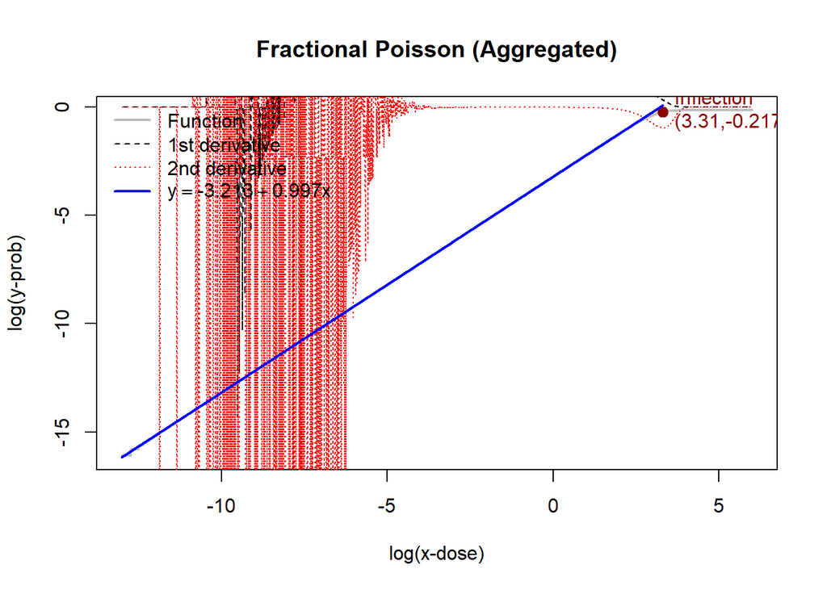

```r
# -------------------------------
# 4. Fractional Poisson Aggregated
# -------------------------------
fp_agg <- function(x){
  x <- 10^x
  p <- 0.72
  alpha1 <- 1106
  log10(p * (1 - exp(-x / alpha1)))
}


ys <- fp_agg(xs)
y1 <- fderiv(fp_agg, xs, n=1, method="backward")
y2 <- fderiv(fp_agg, xs, n=2, method="backward")

inflect_idx <- which(xs > 0)[which.min(y2[xs > 0])] #visually identified range where inflection point is, bounded the search for the minimum in that area to avoid wiggles. which.min looks for rank not value.
inflect_x <- xs[inflect_idx]
inflect_y <- ys[inflect_idx]

plot(xs, ys, type="l", col="gray", lwd=2, main="Fractional Poisson (Aggregated)",
     xlab="log(x-dose)", ylab="log(y-prob)")
lines(xs, y1, col="black", lty=2)
lines(xs, y2, col="red", lty=3)
points(inflect_x, inflect_y, col="darkred", pch=19, cex=1.2)
text(inflect_x, inflect_y, labels=paste0("Inflection\n(", round(inflect_x,3), ",", round(inflect_y,3),")"), pos=4, col="darkred")

linear_idx <- which(xs <= inflect_x)
x_linear <- xs[linear_idx]
y_linear <- ys[linear_idx]
lin_model <- lm(y_linear ~ x_linear)
y_fit <- predict(lin_model)
lines(x_linear, y_fit, col="blue", lwd=2)

slope <- coef(lin_model)[2]
intercept <- coef(lin_model)[1]
formula_text <- bquote(y == .(round(intercept,3)) + .(round(slope,3))*x)

legend("topleft", legend=c("Function","1st derivative","2nd derivative",formula_text),
       col=c("gray","black","red","blue"), lty=c(1,2,3,1), lwd=c(2,1,1,2), bty="n")
```

```r
results <- rbind(results, data.frame(
  Function="fp_agg",
  Max_dose=round(inflect_x,3),
  Linear_Intercept=round(intercept,3),
  Linear_Slope=round(slope,3),
  Name= "Fractional Poisson (Aggregated)",
  Pathogen = "Norovirus"
))
```

## 5. Fractional Poisson (No Aggregation)

Messner et al., 2014; Atmar et al., 2014; Atmar et al., 2008; P=0.72, alpha=1

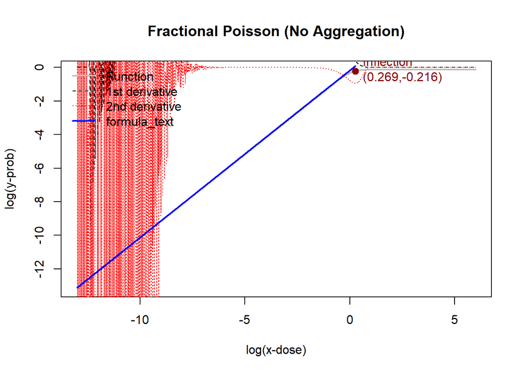

```r
# -------------------------------
# 5. Fractional Poisson (No Aggregation)
# -------------------------------
fp <- function(x){
  x <- 10^x
  p1 <- 0.72
  alpha2 <- 1
  log10(p1 * (1 - exp(-x / alpha2)))
}


ys <- fp(xs)
y1 <- fderiv(fp, xs, n=1, method="backward")
y2 <- fderiv(fp, xs, n=2, method="backward")

inflect_idx <- which(xs > 0)[which.min(y2[xs > 0])] #visually identified range where inflection point is, bounded the search for the minimum in that area to avoid wiggles. which.min looks for rank not value.
inflect_x <- xs[inflect_idx]
inflect_y <- ys[inflect_idx]

plot(xs, ys, type="l", col="gray", lwd=2, main="Fractional Poisson (No Aggregation)",
     xlab="log(x-dose)", ylab="log(y-prob)")
lines(xs, y1, col="black", lty=2)
lines(xs, y2, col="red", lty=3)
points(inflect_x, inflect_y, col="darkred", pch=19, cex=1.2)
text(inflect_x, inflect_y, labels=paste0("Inflection\n(", round(inflect_x,3), ",", round(inflect_y,3),")"), pos=4, col="darkred")

linear_idx <- which(xs <= inflect_x)
x_linear <- xs[linear_idx]
y_linear <- ys[linear_idx]
lin_model <- lm(y_linear ~ x_linear)
y_fit <- predict(lin_model)
lines(x_linear, y_fit, col="blue", lwd=2)

slope <- coef(lin_model)[2]
intercept <- coef(lin_model)[1]
formula_text <- bquote(y == .(round(intercept,3)) + .(round(slope,3))*x)

legend("topleft", legend=c("Function","1st derivative","2nd derivative","formula_text"),
       col=c("gray","black","red","blue"), lty=c(1,2,3,1), lwd=c(2,1,1,2), bty="n")
```

```r
results <- rbind(results, data.frame(
  Function="fp",
  Max_dose=round(inflect_x,3),
  Linear_Intercept=round(intercept,3),
  Linear_Slope=round(slope,3),
  Name="Fractional Poisson (No Aggregation)",
  Pathogen = "Norovirus"
))
```

# Enterovirus Dose-Response Functions

```r
# -------------------------------
# Dose-response model formulas, parameters, and metadata
# -------------------------------

env_info <- data.frame(
  Name = c(
    " Beta-Poisson"
  ),
  Function = c("ent_bp"),
  Formula = c(
    "y = 1 - ((1 + (dose / beta))^(-1 * alpha))"),
  Parameters = c(

    "alpha=0.253, beta=0.426"

  ),
  Citation = c(
    "Ward et al., 1986"
  ),
  stringsAsFactors = FALSE
)

# Display nicely in R Markdown
kable(env_info, caption="Enterovirus dose-response models") %>%
  kable_styling(full_width=F, position="center")
```

Enterovirus dose-response models

| Name | Function | Formula | Parameters | Citation |
| --- | --- | --- | --- | --- |
| Beta-Poisson | ent_bp | y = 1 - ((1 + (dose / beta))^(-1 * alpha)) | alpha=0.253, beta=0.426 | Ward et al., 1986 |

## 1. Beta-Poisson

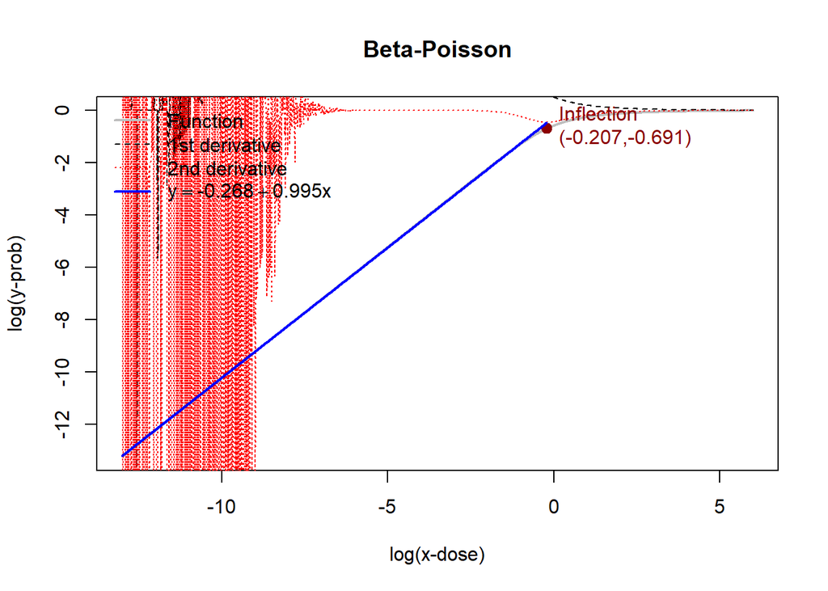

```r
# -------------------------------
# 1.  Beta-Poisson (Ward 1986)
# -------------------------------
ent_bp <- function(x){
  x <- 10^x
  a <- 0.253
  b <- 0.426
  log10(1 - ((1 + (x / b))^(-1 * a)))
}


ys <- ent_bp(xs)
y1 <- fderiv(ent_bp, xs, n=1, method="backward")
y2 <- fderiv(ent_bp, xs, n=2, method="backward")

# Inflection
inflect_idx <- which(xs > -1)[which.min(y2[xs > -1])] #visually identified range where inflection point is, bounded the search for the minimum in that area to avoid wiggles. which.min looks for rank not value.
inflect_x <- xs[inflect_idx]
inflect_y <- ys[inflect_idx]

# Plot
plot(xs, ys, type="l", col="gray", lwd=2, main="Beta-Poisson",
     xlab="log(x-dose)", ylab="log(y-prob)")
lines(xs, y1, col="black", lty=2)
lines(xs, y2, col="red", lty=3)
points(inflect_x, inflect_y, col="darkred", pch=19, cex=1.2)
text(inflect_x, inflect_y, labels=paste0("Inflection\n(", round(inflect_x,3), ",", round(inflect_y,3),")"), pos=4, col="darkred")

# Linear fit
linear_idx <- which(xs <= inflect_x)
x_linear <- xs[linear_idx]
y_linear <- ys[linear_idx]
lin_model <- lm(y_linear ~ x_linear)
y_fit <- predict(lin_model)
lines(x_linear, y_fit, col="blue", lwd=2)

# Add formula
slope <- coef(lin_model)[2]
intercept <- coef(lin_model)[1]
formula_text <- bquote(y == .(round(intercept,3)) + .(round(slope,3))*x)


# Legend
legend("topleft", legend=c("Function","1st derivative","2nd derivative",formula_text),
       col=c("gray","black","red","blue"), lty=c(1,2,3,1), lwd=c(2,1,1,2), bty="n")
```

```r
# Save results
results <- rbind(results, data.frame(
  Function="ent_bp",
  Max_dose=round(inflect_x,3),
  Linear_Intercept=round(intercept,3),
  Linear_Slope=round(slope,3),
  Name="Beta-Poisson",
  Pathogen = "Enterovirus"
))
```

# Adenovirus Dose-Response Functions

```r
# -------------------------------
# Adenovirus dose-response model formulas, parameters, and metadata
# -------------------------------

adeno_info <- data.frame(
  Name = c(
    "Exponential (Crabtree et al., 1997)",
    "Exact Beta-Poisson (Teunis et al., 2016)"
  ),
  Function = c("adeno_exp_crabtree", "adeno_bp_exact"),
  Formula = c(
    "y = 1 - exp(-1 * r * dose)",
    "y = 1 - hyperg_1F1(alpha, alpha+beta, -1 * dose)"
  ),
  Parameters = c(
    "r = 0.4172",
    "alpha = 5.11, beta = 2.8"
  ),
  Citation = c(
    "Crabtree et al., 1997",
    "Teunis et al., 2016"
  ),
  stringsAsFactors = FALSE
)

kable(adeno_info, caption="Adenovirus dose-response models") %>%
  kable_styling(full_width=F, position="center")
```

Adenovirus dose-response models

| Name | Function | Formula | Parameters | Citation |
| --- | --- | --- | --- | --- |
| Exponential (Crabtree et al., 1997) | adeno_exp_crabtree | y = 1 - exp(-1 * r * dose) | r = 0.4172 | Crabtree et al., 1997 |
| Exact Beta-Poisson (Teunis et al., 2016) | adeno_bp_exact | y = 1 - hyperg_1F1(alpha, alpha+beta, -1 * dose) | alpha = 5.11, beta = 2.8 | Teunis et al., 2016 |

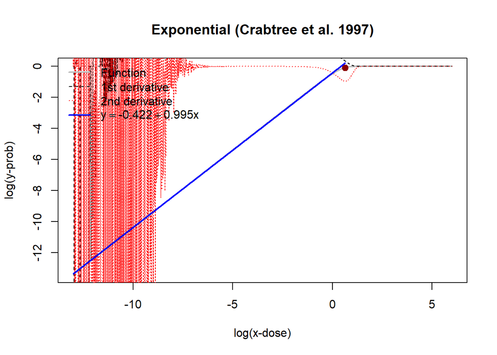

```r
adeno_exp_crabtree <- function(x){
  x <- 10^x; r <- 0.4172
  log10(1 - exp(-1 * r * x))
}

ys <- adeno_exp_crabtree(xs)
y1 <- fderiv(adeno_exp_crabtree, xs, n=1, method="backward")
y2 <- fderiv(adeno_exp_crabtree, xs, n=2, method="backward")
#inflect_idx <- which.min(y2)
inflect_idx <- which(xs > -1)[which.min(y2[xs > -1])] #this narrows the range where the minimum index value is found, to those where the value of x (not the index) are greater than in this case -5. Can be specified using visual examination of the curve
inflect_x <- xs[inflect_idx]; inflect_y <- ys[inflect_idx]
plot(xs, ys, type="l", col="gray", lwd=2, main="Exponential (Crabtree et al. 1997)",
     xlab="log(x-dose)", ylab="log(y-prob)")
lines(xs, y1, col="black", lty=2); lines(xs, y2, col="red", lty=3)
points(inflect_x, inflect_y, col="darkred", pch=19, cex=1.2)
linear_idx <- which(xs <= inflect_x)
lin_model <- lm(ys[linear_idx] ~ xs[linear_idx])
lines(xs[linear_idx], predict(lin_model), col="blue", lwd=2)
slope <- coef(lin_model)[2]; intercept <- coef(lin_model)[1]
legend("topleft", legend=c("Function","1st derivative","2nd derivative",
       bquote(y == .(round(intercept,3)) + .(round(slope,3))*x)),
       col=c("gray","black","red","blue"), lty=c(1,2,3,1), lwd=c(2,1,1,2), bty="n")
```

```r
results <- rbind(results, data.frame(
  Function="adeno_exp_crabtree", Max_dose=round(inflect_x,3),
  Linear_Intercept=round(intercept,3), Linear_Slope=round(slope,3),
  Name="Exponential (Crabtree et al. 1997)", Pathogen="Adenovirus"))
```

## 2. Exact Beta-Poisson (Teunis et al., 2016)

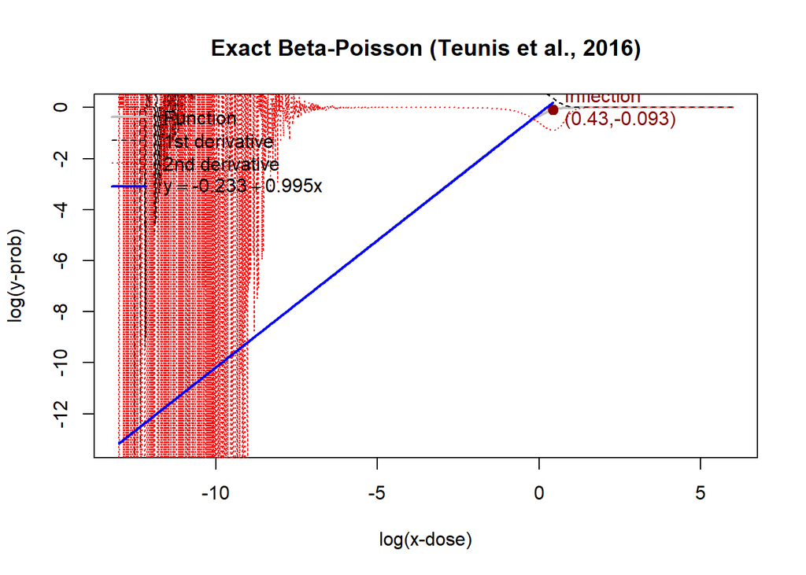

```r
adeno_bp_exact <- function(x){
  x <- 10^x
  alpha <- 5.11
  beta <- 2.8
  log10(1 - hyperg_1F1(alpha, (alpha + beta), -1 * x))
}


ys <- adeno_bp_exact(xs)
y1 <- fderiv(adeno_bp_exact, xs, n=1, method="backward")
y2 <- fderiv(adeno_bp_exact, xs, n=2, method="backward")

# Inflection
inflect_idx <- which(xs > 0)[which.min(y2[xs > 0])] #visually identified range where inflection point is, bounded the search for the minimum in that area to avoid wiggles. which.min looks for rank not value.
inflect_x <- xs[inflect_idx]
inflect_y <- ys[inflect_idx]

# Plot
plot(xs, ys, type="l", col="gray", lwd=2, main="Exact Beta-Poisson (Teunis et al., 2016)",
     xlab="log(x-dose)", ylab="log(y-prob)")
lines(xs, y1, col="black", lty=2)
lines(xs, y2, col="red", lty=3)
points(inflect_x, inflect_y, col="darkred", pch=19, cex=1.2)
text(inflect_x, inflect_y, labels=paste0("Inflection\n(", round(inflect_x,3), ",", round(inflect_y,3),")"), pos=4, col="darkred")

# Linear fit
linear_idx <- which(xs <= inflect_x)
x_linear <- xs[linear_idx]
y_linear <- ys[linear_idx]
lin_model <- lm(y_linear ~ x_linear)
y_fit <- predict(lin_model)
lines(x_linear, y_fit, col="blue", lwd=2)

# Add formula
slope <- coef(lin_model)[2]
intercept <- coef(lin_model)[1]
formula_text <- bquote(y == .(round(intercept,3)) + .(round(slope,3))*x)

# Legend
legend("topleft", legend=c("Function","1st derivative","2nd derivative",formula_text),
       col=c("gray","black","red","blue"), lty=c(1,2,3,1), lwd=c(2,1,1,2), bty="n")
```

```r
# Save results
results <- rbind(results, data.frame(
  Function="adeno_bp_exact",
  Max_dose=round(inflect_x,3),
  Linear_Intercept=round(intercept,3),
  Linear_Slope=round(slope,3),
  Name="Exact Beta-Poisson (Teunis et al., 2016)",
  Pathogen="Adenovirus"
))
```

# Giardia Dose-Response Functions

```r
# -------------------------------
# Dose-response model formulas, parameters, and metadata
# -------------------------------

gia_info <- data.frame(
  Name = c(
    "Exponential"
  ),
  Function = c("gia_exp"),
  Formula = c(
    "y = 1-exp(-1 * r * dose)"),
  Parameters = c(

    "r = 0.0199"

  ),
  Citation = c(
    "Teunis et al., 1997"
  ),
  stringsAsFactors = FALSE
)

# Display nicely in R Markdown
kable(gia_info, caption="Giardia dose-response models") %>%
  kable_styling(full_width=F, position="left")
```

Giardia dose-response models

| Name | Function | Formula | Parameters | Citation |
| --- | --- | --- | --- | --- |
| Exponential | gia_exp | y = 1-exp(-1 * r * dose) | r = 0.0199 | Teunis et al., 1997 |

## 1. Exponential

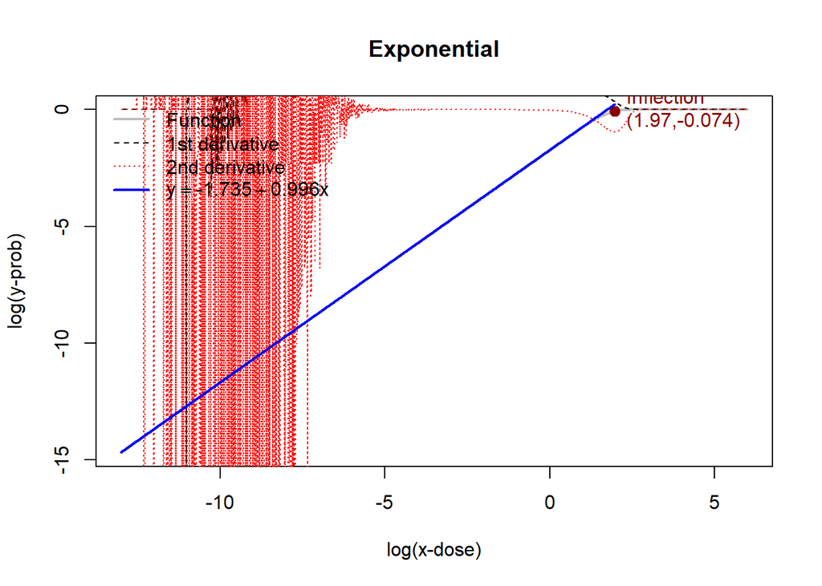

```r
# -------------------------------
# 1.  Exponential (Teunis et al. 1997)
# -------------------------------
gia_exp <- function(x){
  x <- 10^x
  r <- 0.0199
  log10(1-exp(-1 * r * x))
}


ys <- gia_exp(xs)
y1 <- fderiv(gia_exp, xs, n=1, method="backward")
y2 <- fderiv(gia_exp, xs, n=2, method="backward")

# Inflection
inflect_idx <- which(xs > 0)[which.min(y2[xs > 0])] #visually identified range where inflection point is, bounded the search for the minimum in that area to avoid wiggles. which.min looks for rank not value.
inflect_x <- xs[inflect_idx]
inflect_y <- ys[inflect_idx]

# Plot
plot(xs, ys, type="l", col="gray", lwd=2, main="Exponential",
     xlab="log(x-dose)", ylab="log(y-prob)")
lines(xs, y1, col="black", lty=2)
lines(xs, y2, col="red", lty=3)
points(inflect_x, inflect_y, col="darkred", pch=19, cex=1.2)
text(inflect_x, inflect_y, labels=paste0("Inflection\n(", round(inflect_x,3), ",", round(inflect_y,3),")"), pos=4, col="darkred")

# Linear fit
linear_idx <- which(xs <= inflect_x)
x_linear <- xs[linear_idx]
y_linear <- ys[linear_idx]
lin_model <- lm(y_linear ~ x_linear)
y_fit <- predict(lin_model)
lines(x_linear, y_fit, col="blue", lwd=2)

# Add formula
slope <- coef(lin_model)[2]
intercept <- coef(lin_model)[1]
formula_text <- bquote(y == .(round(intercept,3)) + .(round(slope,3))*x)


# Legend
legend("topleft", legend=c("Function","1st derivative","2nd derivative",formula_text),
       col=c("gray","black","red","blue"), lty=c(1,2,3,1), lwd=c(2,1,1,2), bty="n")
```

```r
# Save results
results <- rbind(results, data.frame(
  Function="gia_exp",
  Max_dose=round(inflect_x,3),
  Linear_Intercept=round(intercept,3),
  Linear_Slope=round(slope,3),
  Name="Exponential",
  Pathogen = "Giardia"
))
```

# Cryptosporidium Dose-Response Functions

```r
# -------------------------------
# Cryptosporidium dose-response model formulas, parameters, and metadata
# -------------------------------

crypto_info <- data.frame(
  Name = c(
    "Exponential (EPA 2006)",
    "Exponential (Haas et al., 1999; Barbeau et al., 2000; Zhang et al., 2012)",
    "Fractional Poisson (Messner & Berger, 2016)",
    "Beta-Poisson (Messner & Berger, 2016)",
    "Exponential with Immunity (Messner & Berger, 2016)"
  ),
  Function = c(
    "crypto_exp_epa",
    "crypto_exp_haas",
    "crypto_fracpois",
    "crypto_bp",
    "crypto_exp_immunity"
  ),
  Formula = c(
    "y = 1 - exp(-1 * r * dose)",
    "y = 1 - exp(-1 * r * dose)",
    "y = p * (1 - exp((-1 * dose) / alpha))",
    "y = 1 - (1 + (dose / beta))^(-alpha)",
    "y = p * (1 - exp(-1 * r * dose))"
  ),
  Parameters = c(
    "r = 0.09",
    "r = 0.00419",
    "p = 0.737, alpha = 1",
    "alpha = 0.116, beta = 0.121",
    "p = 0.737, r = 0.608"
  ),
  Citation = c(
    "EPA, 2006",
    "Haas et al., 1999; Barbeau et al., 2000; Zhang et al., 2012",
    "Messner & Berger, 2016",
    "Messner & Berger, 2016",
    "Messner & Berger, 2016"
  ),
  stringsAsFactors = FALSE
)

kable(crypto_info, caption="Cryptosporidium dose-response models") %>%
  kable_styling(full_width=F, position="center")
```

Cryptosporidium dose-response models

| Name | Function | Formula | Parameters | Citation |
| --- | --- | --- | --- | --- |
| Exponential (EPA 2006) | crypto_exp_epa | y = 1 - exp(-1 * r * dose) | r = 0.09 | EPA, 2006 |
| Exponential (Haas et al., 1999; Barbeau et al., 2000; Zhang et al., 2012) | crypto_exp_haas | y = 1 - exp(-1 * r * dose) | r = 0.00419 | Haas et al., 1999; Barbeau et al., 2000; Zhang et al., 2012 |
| Fractional Poisson (Messner & Berger, 2016) | crypto_fracpois | y = p * (1 - exp((-1 * dose) / alpha)) | p = 0.737, alpha = 1 | Messner & Berger, 2016 |
| Beta-Poisson (Messner & Berger, 2016) | crypto_bp | y = 1 - (1 + (dose / beta))^(-alpha) | alpha = 0.116, beta = 0.121 | Messner & Berger, 2016 |
| Exponential with Immunity (Messner & Berger, 2016) | crypto_exp_immunity | y = p * (1 - exp(-1 * r * dose)) | p = 0.737, r = 0.608 | Messner & Berger, 2016 |

## 1. Exponential (EPA 2006)

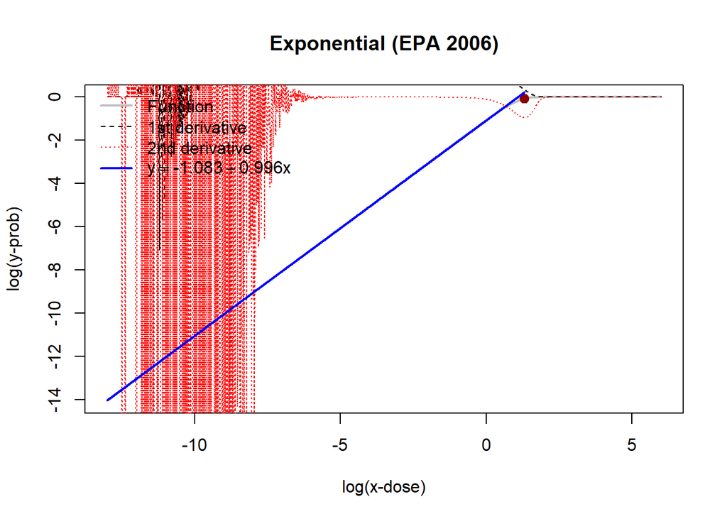

```r
crypto_exp_epa <- function(x){
  x <- 10^x
  r <- 0.09
  log10(1 - exp(-1 * r * x))
}

ys <- crypto_exp_epa(xs)
y1 <- fderiv(crypto_exp_epa, xs, n=1, method="backward")
y2 <- fderiv(crypto_exp_epa, xs, n=2, method="backward")
inflect_idx <- which(xs > 0)[which.min(y2[xs > 0])] #visually identified range where inflection point is, bounded the search for the minimum in that area to avoid wiggles. which.min looks for rank not value.
inflect_x <- xs[inflect_idx]; inflect_y <- ys[inflect_idx]
plot(xs, ys, type="l", col="gray", lwd=2, main="Exponential (EPA 2006)",
     xlab="log(x-dose)", ylab="log(y-prob)")
lines(xs, y1, col="black", lty=2); lines(xs, y2, col="red", lty=3)
points(inflect_x, inflect_y, col="darkred", pch=19, cex=1.2)
linear_idx <- which(xs <= inflect_x)
lin_model <- lm(ys[linear_idx] ~ xs[linear_idx])
lines(xs[linear_idx], predict(lin_model), col="blue", lwd=2)
slope <- coef(lin_model)[2]; intercept <- coef(lin_model)[1]
legend("topleft", legend=c("Function","1st derivative","2nd derivative",
       bquote(y == .(round(intercept,3)) + .(round(slope,3))*x)),
       col=c("gray","black","red","blue"), lty=c(1,2,3,1), lwd=c(2,1,1,2), bty="n")
```

```r
results <- rbind(results, data.frame(
  Function="crypto_exp_epa", Max_dose=round(inflect_x,3),
  Linear_Intercept=round(intercept,3), Linear_Slope=round(slope,3),
  Name="Exponential (EPA 2006)", Pathogen="Cryptosporidium"))
```

## 2. Exponential (Haas et al., 1999; Barbeau et al., 2000; Zhang et al., 2012)

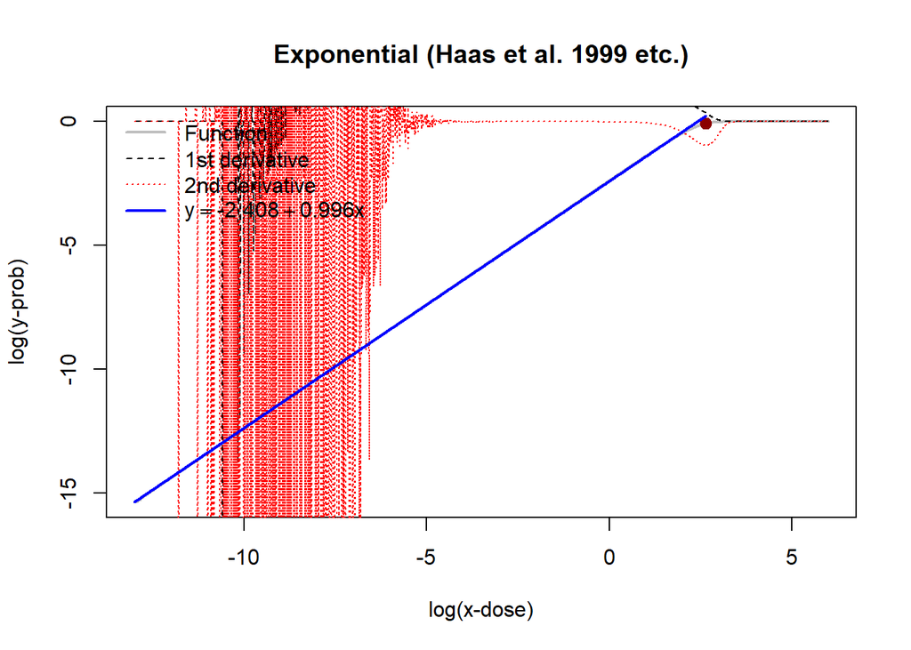

```r
crypto_exp_haas <- function(x){
  x <- 10^x; r <- 0.00419
  log10(1 - exp(-1 * r * x))
}

ys <- crypto_exp_haas(xs)
y1 <- fderiv(crypto_exp_haas, xs, n=1, method="backward")
y2 <- fderiv(crypto_exp_haas, xs, n=2, method="backward")
inflect_idx <- which(xs > 0)[which.min(y2[xs > 0])] #visually identified range where inflection point is, bounded the search for the minimum in that area to avoid wiggles. which.min looks for rank not value.
inflect_x <- xs[inflect_idx]; inflect_y <- ys[inflect_idx]
plot(xs, ys, type="l", col="gray", lwd=2, main="Exponential (Haas et al. 1999 etc.)",
     xlab="log(x-dose)", ylab="log(y-prob)")
lines(xs, y1, col="black", lty=2); lines(xs, y2, col="red", lty=3)
points(inflect_x, inflect_y, col="darkred", pch=19, cex=1.2)
linear_idx <- which(xs <= inflect_x)
lin_model <- lm(ys[linear_idx] ~ xs[linear_idx])
lines(xs[linear_idx], predict(lin_model), col="blue", lwd=2)
slope <- coef(lin_model)[2]; intercept <- coef(lin_model)[1]
legend("topleft", legend=c("Function","1st derivative","2nd derivative",
       bquote(y == .(round(intercept,3)) + .(round(slope,3))*x)),
       col=c("gray","black","red","blue"), lty=c(1,2,3,1), lwd=c(2,1,1,2), bty="n")
```

```r
results <- rbind(results, data.frame(
  Function="crypto_exp_haas", Max_dose=round(inflect_x,3),
  Linear_Intercept=round(intercept,3), Linear_Slope=round(slope,3),
  Name="Exponential (Haas/Barbeau/Zhang)", Pathogen="Cryptosporidium"))
```

## 3. Fractional Poisson (Messner & Berger, 2016)

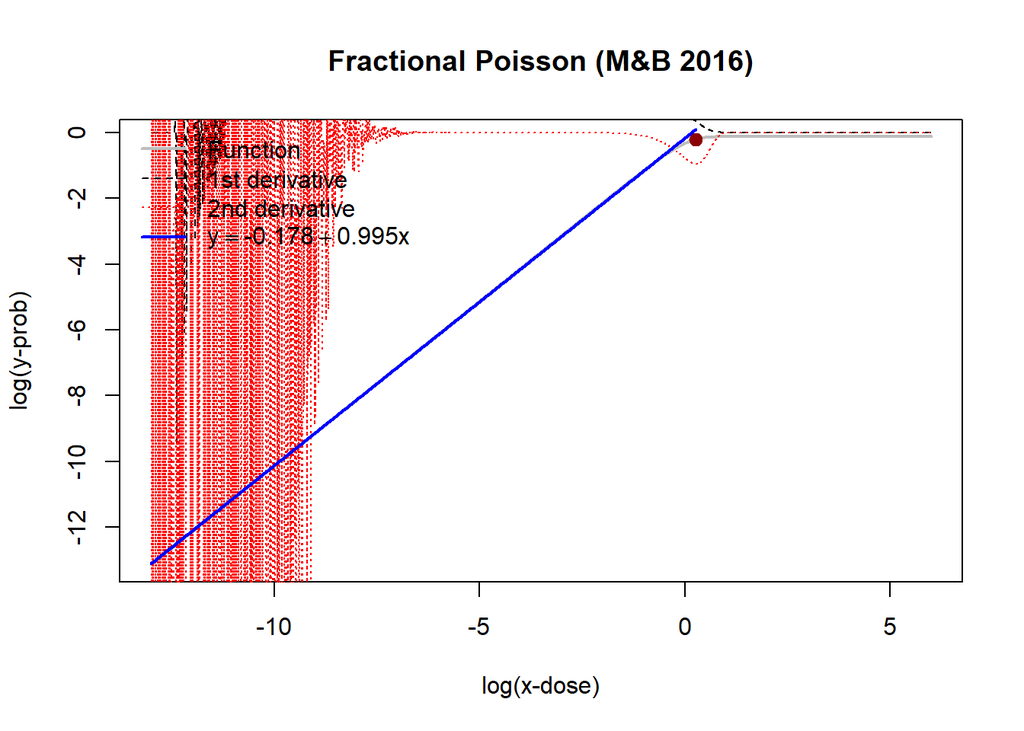

```r
crypto_fracpois <- function(x){
  x <- 10^x; p <- 0.737; alpha <- 1
  log10(p * (1 - exp((-1 * x) / alpha)))
}

ys <- crypto_fracpois(xs)
y1 <- fderiv(crypto_fracpois, xs, n=1, method="backward")
y2 <- fderiv(crypto_fracpois, xs, n=2, method="backward")
inflect_idx <- which(xs > -1)[which.min(y2[xs > -1])] #visually identified range where inflection point is, bounded the search for the minimum in that area to avoid wiggles. which.min looks for rank not value.
inflect_x <- xs[inflect_idx]; inflect_y <- ys[inflect_idx]
plot(xs, ys, type="l", col="gray", lwd=2, main="Fractional Poisson (M&B 2016)",
     xlab="log(x-dose)", ylab="log(y-prob)")
lines(xs, y1, col="black", lty=2); lines(xs, y2, col="red", lty=3)
points(inflect_x, inflect_y, col="darkred", pch=19, cex=1.2)
linear_idx <- which(xs <= inflect_x)
lin_model <- lm(ys[linear_idx] ~ xs[linear_idx])
lines(xs[linear_idx], predict(lin_model), col="blue", lwd=2)
slope <- coef(lin_model)[2]; intercept <- coef(lin_model)[1]
legend("topleft", legend=c("Function","1st derivative","2nd derivative",
       bquote(y == .(round(intercept,3)) + .(round(slope,3))*x)),
       col=c("gray","black","red","blue"), lty=c(1,2,3,1), lwd=c(2,1,1,2), bty="n")
```

```r
results <- rbind(results, data.frame(
  Function="crypto_fracpois", Max_dose=round(inflect_x,3),
  Linear_Intercept=round(intercept,3), Linear_Slope=round(slope,3),
  Name="Fractional Poisson (M&B 2016)", Pathogen="Cryptosporidium"))
```

## 4. Beta-Poisson (Messner & Berger, 2016)

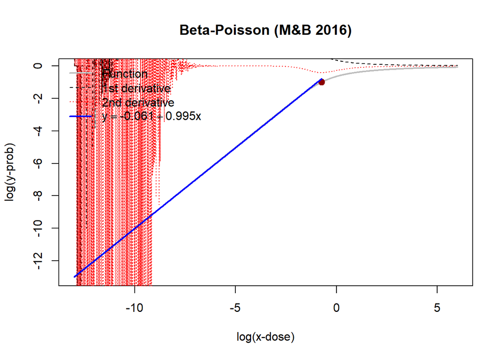

```r
crypto_bp <- function(x){
  x <- 10^x; alpha <- 0.116; beta <- 0.121
  log10(1 - (1 + (x / beta))^(-alpha))
}

ys <- crypto_bp(xs)
y1 <- fderiv(crypto_bp, xs, n=1, method="backward")
y2 <- fderiv(crypto_bp, xs, n=2, method="backward")
inflect_idx <- which(xs > -1)[which.min(y2[xs > -1])] #visually identified range where inflection point is, bounded the search for the minimum in that area to avoid wiggles. which.min looks for rank not value.
inflect_x <- xs[inflect_idx]; inflect_y <- ys[inflect_idx]
plot(xs, ys, type="l", col="gray", lwd=2, main="Beta-Poisson (M&B 2016)",
     xlab="log(x-dose)", ylab="log(y-prob)")
lines(xs, y1, col="black", lty=2); lines(xs, y2, col="red", lty=3)
points(inflect_x, inflect_y, col="darkred", pch=19, cex=1.2)
linear_idx <- which(xs <= inflect_x)
lin_model <- lm(ys[linear_idx] ~ xs[linear_idx])
lines(xs[linear_idx], predict(lin_model), col="blue", lwd=2)
slope <- coef(lin_model)[2]; intercept <- coef(lin_model)[1]
legend("topleft", legend=c("Function","1st derivative","2nd derivative",
       bquote(y == .(round(intercept,3)) + .(round(slope,3))*x)),
       col=c("gray","black","red","blue"), lty=c(1,2,3,1), lwd=c(2,1,1,2), bty="n")
```

```r
results <- rbind(results, data.frame(
  Function="crypto_bp", Max_dose=round(inflect_x,3),
  Linear_Intercept=round(intercept,3), Linear_Slope=round(slope,3),
  Name="Beta-Poisson (M&B 2016)", Pathogen="Cryptosporidium"))
```

## 5. Exponential with Immunity (Messner & Berger, 2016)

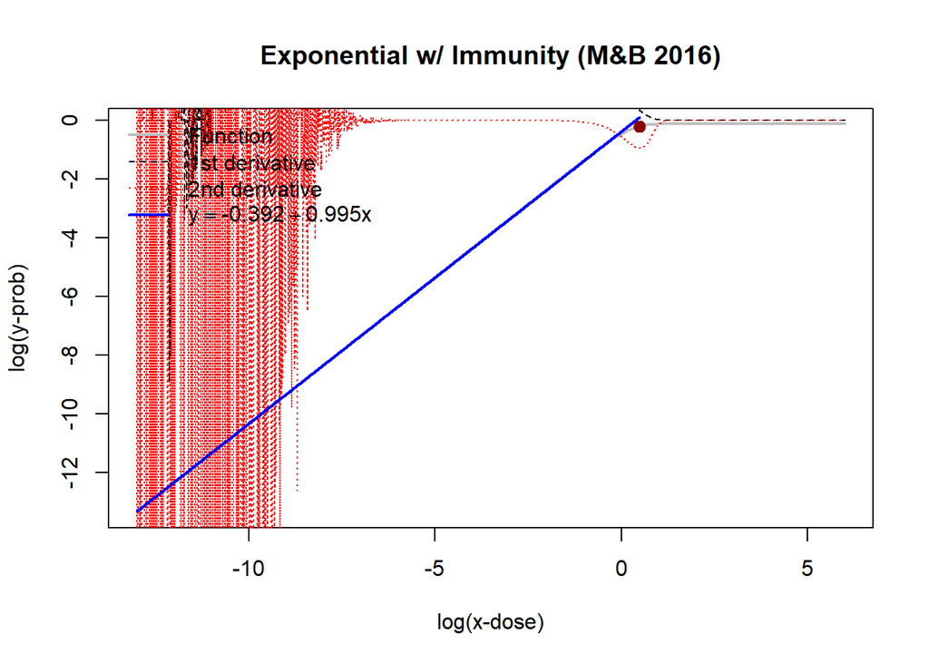

```r
crypto_exp_immunity <- function(x){
  x <- 10^x; p <- 0.737; r <- 0.608
  log10(p * (1 - exp(-1 * r * x)))
}
ys <- crypto_exp_immunity(xs)
y1 <- fderiv(crypto_exp_immunity, xs, n=1, method="backward")
y2 <- fderiv(crypto_exp_immunity, xs, n=2, method="backward")
inflect_idx <- which(xs > 0)[which.min(y2[xs > 0])] #visually identified range where inflection point is, bounded the search for the minimum in that area to avoid wiggles. which.min looks for rank not value.
inflect_x <- xs[inflect_idx]; inflect_y <- ys[inflect_idx]
plot(xs, ys, type="l", col="gray", lwd=2, main="Exponential w/ Immunity (M&B 2016)",
     xlab="log(x-dose)", ylab="log(y-prob)")
lines(xs, y1, col="black", lty=2); lines(xs, y2, col="red", lty=3)
points(inflect_x, inflect_y, col="darkred", pch=19, cex=1.2)
linear_idx <- which(xs <= inflect_x)
lin_model <- lm(ys[linear_idx] ~ xs[linear_idx])
lines(xs[linear_idx], predict(lin_model), col="blue", lwd=2)
slope <- coef(lin_model)[2]; intercept <- coef(lin_model)[1]
legend("topleft", legend=c("Function","1st derivative","2nd derivative",
       bquote(y == .(round(intercept,3)) + .(round(slope,3))*x)),
       col=c("gray","black","red","blue"), lty=c(1,2,3,1), lwd=c(2,1,1,2), bty="n")
```

```r
results <- rbind(results, data.frame(
  Function="crypto_exp_immunity", Max_dose=round(inflect_x,3),
  Linear_Intercept=round(intercept,3), Linear_Slope=round(slope,3),
  Name="Exponential with Immunity (M&B 2016)", Pathogen="Cryptosporidium"))
```

# Summary Table

```r
# -------------------------------
# Summary Table
# -------------------------------


# Define thresholds in log10
daily_log <- -6.57
annual_log <- -4

# Prepare results table
results_clean <- results %>%
  select(
    Pathogen,
    Name,
    Function,
    Max_dose,
    Linear_Slope,
    Linear_Intercept
  ) %>%
  rename(
    `Max Dose (log10IU)` = Max_dose,
    Slope = Linear_Slope,
    Intercept = Linear_Intercept
  ) %>%
  mutate(
    `Max dose (IU)` = round(10^`Max Dose (log10IU)`,3),
    `Daily threshold dose (log10IU)` = round(((daily_log - Intercept) / Slope),3),
    `Daily threshold concentration (log10IU/L)` = round(log10(10^`Daily threshold dose (log10IU)`/2.5),3),
   # `Annual threshold dose (log10IU)` = round(((annual_log - Intercept) / Slope),3)
  ) %>%
 `rownames<-`(NULL)  # remove any row names

# Create interactive table
datatable(
  results_clean,
  caption = "Linear regression parameters for all dose-response functions",
  rownames = FALSE,
  options = list(
    pageLength = 10,
    autoWidth = TRUE,
    searching = TRUE,
    ordering = TRUE
  )
)
```

| Pathogen | Name | Function | Max Dose (log10IU) | Slope | Intercept | Max dose (IU) | Daily threshold dose (log10IU) | Daily threshold concentration (log10IU/L) |
| --- | --- | --- | --- | --- | --- | --- | --- | --- |
| Norovirus | Approximate Beta-Poisson | approx_bp | 1.704 | 0.997 | -2.52 | 50.582 | -4.062 | -4.46 |
| Norovirus | Hypergeometric (Teunis 2008) | hyper | 0.269 | 0.995 | -0.419 | 1.858 | -6.182 | -6.58 |
| Norovirus | Hypergeometric (Teunis 2020) | new_hyper | 0.383 | 0.996 | -0.506 | 2.415 | -6.088 | -6.486 |
| Norovirus | Fractional Poisson (Aggregated) | fp_agg | 3.31 | 0.997 | -3.213 | 2041.738 | -3.367 | -3.765 |
| Norovirus | Fractional Poisson (No Aggregation) | fp | 0.269 | 0.995 | -0.188 | 1.858 | -6.414 | -6.812 |
| Enterovirus | Beta-Poisson | ent_bp | -0.207 | 0.995 | -0.268 | 0.621 | -6.334 | -6.732 |
| Adenovirus | Exponential (Crabtree et al. 1997) | adeno_exp_crabtree | 0.649 | 0.995 | -0.422 | 4.457 | -6.179 | -6.577 |
| Adenovirus | Exact Beta-Poisson (Teunis et al., 2016) | adeno_bp_exact | 0.43 | 0.995 | -0.233 | 2.692 | -6.369 | -6.767 |
| Giardia | Exponential | gia_exp | 1.97 | 0.996 | -1.735 | 93.325 | -4.854 | -5.252 |
| Cryptosporidium | Exponential (EPA 2006) | crypto_exp_epa | 1.314 | 0.996 | -1.083 | 20.606 | -5.509 | -5.907 |

[output cut: 4 more lines]

# Plot comparison

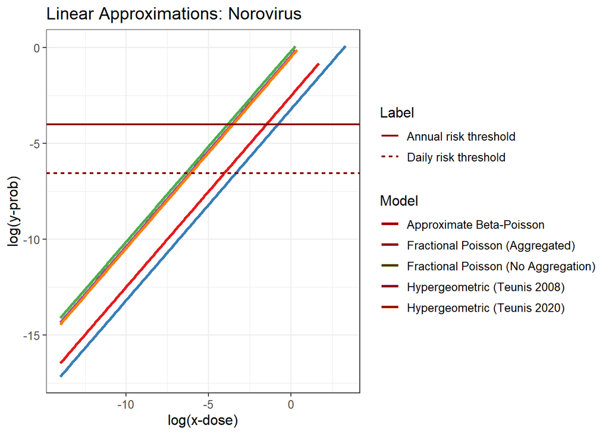

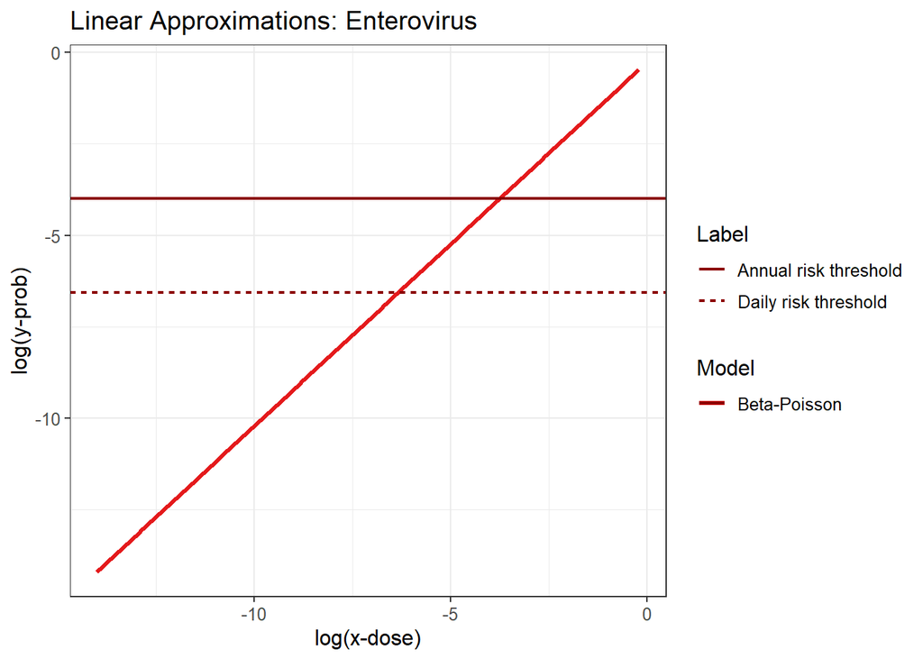

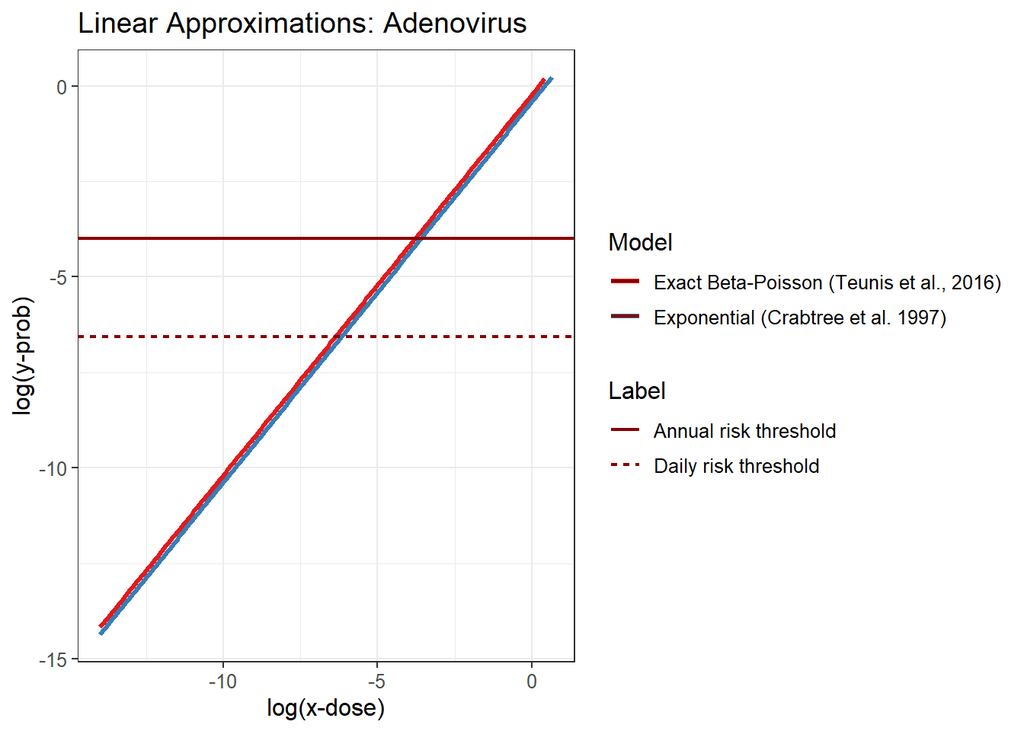

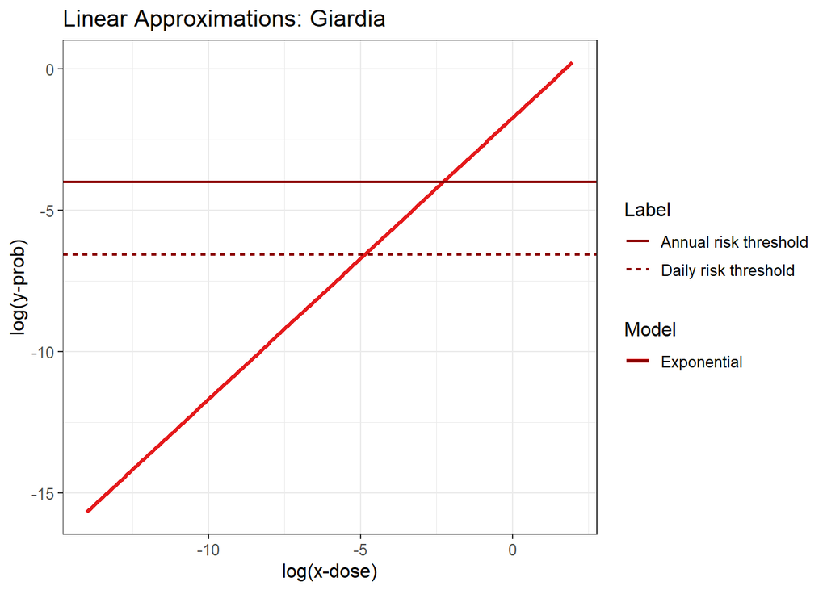

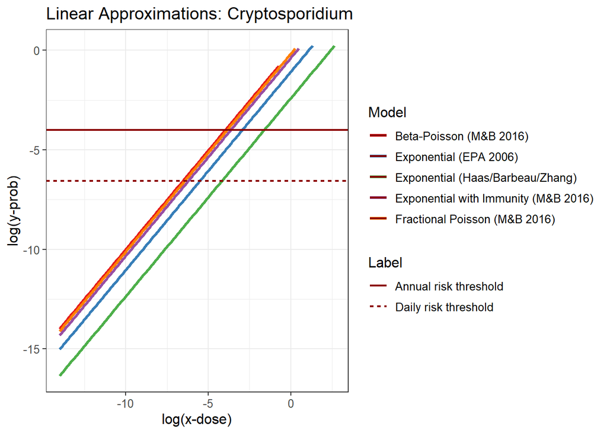

```r
# Prepare data for plotting
linear_plot_data <- results %>%
  rowwise() %>%
  do({
    data.frame(
      x = seq(-14, .$Max_dose, length.out = 200),  # from -14 to Max_dose
      y = .$Linear_Intercept + .$Linear_Slope * seq(-14, .$Max_dose, length.out = 200),
      Model = .$Name,
      Pathogen = .$Pathogen
    )
  })
pathogens <- unique(results$Pathogen)

for(pd in pathogens){
  data_subset <- linear_plot_data %>% filter(Pathogen == pd)

  ggplot(data_subset, aes(x=x, y=y, color=Model)) +
    geom_line(size=1.2) +
    labs(title = paste("Linear Approximations:", pd),
         x="log(x-dose)", y="log(y-prob)") +
    theme_bw() +
    scale_color_brewer(palette="Set1") +
    theme(text = element_text(size=12), legend.position="right") +
    geom_hline(
      data = data.frame(
        yintercept = c(-6.57, -4),
        Label = c("Daily risk threshold", "Annual risk threshold")
      ),
      aes(yintercept=yintercept, linetype=Label),
      color="red4",
      size=0.8,
      show.legend=TRUE
    ) -> p

  print(p)
}
```

```r
knitr::knit_exit()
```